# R Notebook

### Classification

#### 3. Are autumn expeditions more likely to fail than spring expeditions?

This is a classification problem: - Response variable: `SUCCESS1` (TRUE/FALSE) - Predictor: `SEASON_FACTOR` (filtered to Spring and Autumn)

Understanding this relationship can help climbers plan their expeditions for better outcomes.

```r
data_season <- exped_full %>%
  filter(SEASON_FACTOR %in% c("Spring", "Autumn")) %>%
  select(SUCCESS1, SEASON_FACTOR, TOTMEMBERS, ROPE, O2USED) %>%
  drop_na()

table(data_season$SUCCESS1)
```

```
FALSE  TRUE
 3151  4482
```

```r
prop.table(table(data_season$SUCCESS1))
```

```
    FALSE      TRUE
0.4128128 0.5871872
```

```r
data_season <- data_season %>%
  mutate(SUCCESS1 = as.factor(SUCCESS1))
```

```r
# Success rate by season
data_season %>%
  group_by(SEASON_FACTOR) %>%
  summarise(success_rate = mean(SUCCESS1), n = n())
```

[output not shown]

| SEASON_FACTOR | success_rate | n |
| --- | --- | --- |
| Autumn | NA | 3738 |
| Spring | NA | 3895 |

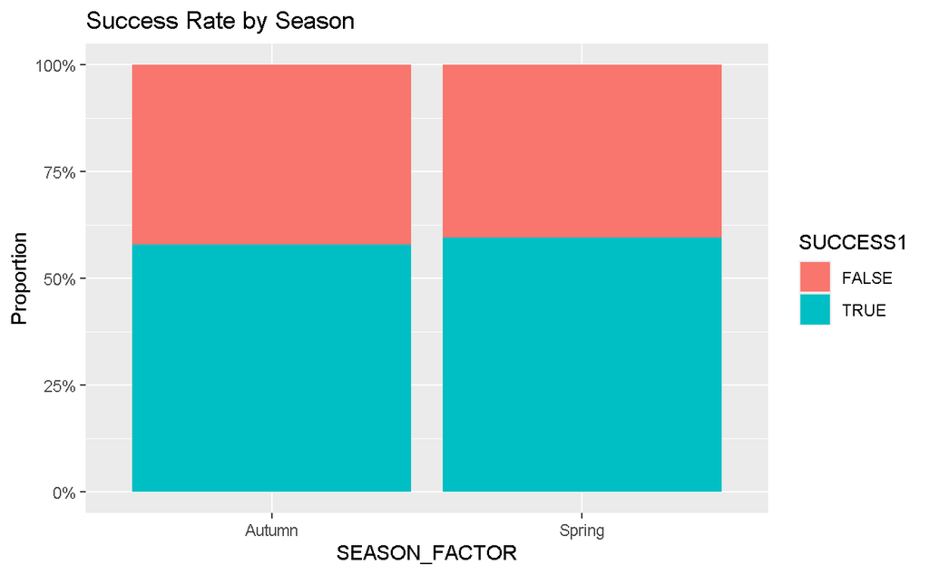

```r
# Bar chart
ggplot(data_season, aes(x = SEASON_FACTOR, fill = SUCCESS1)) +
  geom_bar(position = "fill") +
  scale_y_continuous(labels = scales::percent) +
  labs(title = "Success Rate by Season", y = "Proportion")
```

The bar plot above illustrates the proportion of successful and unsuccessful expeditions for the **Spring** and **Autumn** seasons. While success appears slightly more frequent in **Spring**, the difference is relatively subtle.

This visualization motivates the need for a formal statistical test (e.g., **logistic regression**) to determine whether the observed difference is statistically significant.

```r
infer_test <- data_season %>%
  specify(SUCCESS1 ~ SEASON_FACTOR, success = "TRUE") %>%
  generate(reps = 1000, type = "bootstrap") %>%
  calculate(stat = "diff in props", order = c("Autumn", "Spring"))
```

```
Dropping unused factor levels c("Summer", "Winter") from the supplied explanatory variable 'SEASON_FACTOR'.
```

```r
get_confidence_interval(infer_test, level = 0.95, type = "percentile")
```

| lower_ci | upper_ci |
| --- | --- |
| -0.04086421 | 0.005389472 |

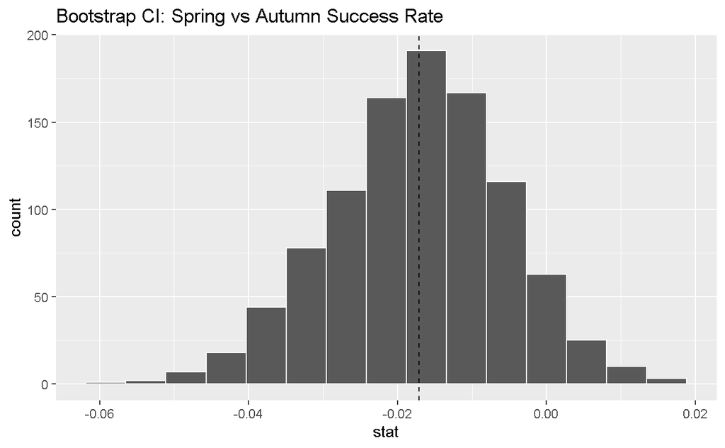

```r
visualize(infer_test) +
  geom_vline(xintercept = mean(infer_test$stat), linetype = "dashed") +
  labs(title = "Bootstrap CI: Spring vs Autumn Success Rate")
```

We use **bootstrap resampling** to estimate the 95% confidence interval for the **difference in success proportions** between autumn and spring expeditions.

The statistic of interest is the difference in porportions between Autumn and Spring.

We now split the dataset and prepare it for the logistic regression

```r
set.seed(123)
split_season <- initial_split(data_season, prop = 0.8)
train_season <- training(split_season)
test_season  <- testing(split_season)
```

```r
rec_season <- recipe(SUCCESS1 ~ ., data = train_season) %>%
  step_dummy(all_nominal_predictors(), one_hot = TRUE)
```

**Logistic Regression**

```r
log_model <- logistic_reg() %>%
  set_engine("glm") %>%
  set_mode("classification")

wf_log <- workflow() %>%
  add_model(log_model) %>%
  add_recipe(rec_season)

fit_log <- fit(wf_log, data = train_season)
```

```r
log_preds <- predict(fit_log, test_season, type = "prob") %>%
  bind_cols(predict(fit_log, test_season)) %>%
  bind_cols(test_season)
```

Evaluation

```r
log_metrics <- log_preds %>%
  metrics(truth = SUCCESS1, estimate = .pred_class) %>%
  bind_rows(precision(log_preds, truth = SUCCESS1, estimate = .pred_class)) %>%
  bind_rows(recall(log_preds, truth = SUCCESS1, estimate = .pred_class)) %>%
  bind_rows(f_meas(log_preds, truth = SUCCESS1, estimate = .pred_class))

log_metrics
```

| .metric | .estimator | .estimate |
| --- | --- | --- |
| accuracy | binary | 0.6994106 |
| kap | binary | 0.3810919 |
| precision | binary | 0.6595745 |
| recall | binary | 0.6162080 |
| f_meas | binary | 0.6371542 |

We fit a **logistic regression** to predict the probability of expedition success (`SUCCESS1`) based on predictors such as **season**, **team size**, **oxygen use**, and **rope usage**, focusing only on **spring** and **autumn** expeditions.

- **Accuracy**: 0.699 — This means the model correctly predicts success or failure about 70% of the time

These results suggest that season, along with a few other predictors, offers **some discriminatory power** for predicting expedition success, but there’s still **room for improvement**, perhaps using non-linear models or additional variables.

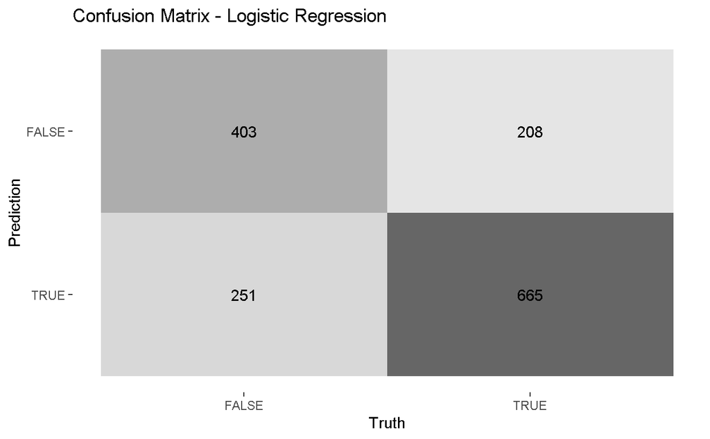

```r
# Confusion matrix
conf_mat(log_preds, truth = SUCCESS1, estimate = .pred_class) %>%
  autoplot(type = "heatmap") +
  labs(title = "Confusion Matrix - Logistic Regression")
```

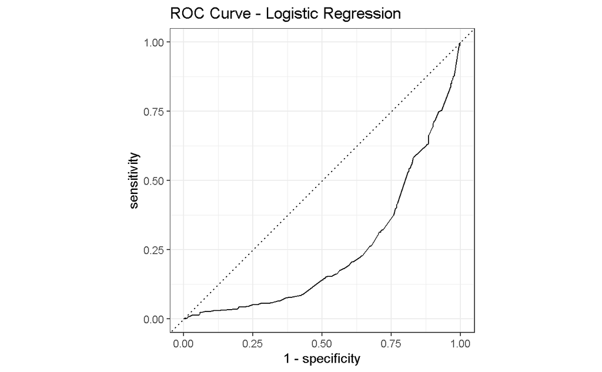

```r
# ROC Curve
log_preds %>%
  roc_curve(truth = SUCCESS1, .pred_TRUE) %>%
  autoplot() +
  ggtitle("ROC Curve - Logistic Regression")
```

The **confusion matrix** reveals a reasonable balance between correctly classified successes and failures, although there are some false positives and false negatives.

```r
# Naive Bayes (Optional Comparison)
library("discrim")
nb_model <- naive_Bayes() %>%
  set_engine("klaR") %>%
  set_mode("classification")

wf_nb <- workflow() %>%
  add_model(nb_model) %>%
  add_recipe(rec_season)

fit_nb <- fit(wf_nb, data = train_season)

nb_preds <- predict(fit_nb, test_season, type = "prob") %>%
  bind_cols(predict(fit_nb, test_season)) %>%
  bind_cols(test_season)
```

```r
# Evaluation
metrics(nb_preds, truth = SUCCESS1, estimate = .pred_class)
```

| .metric | .estimator | .estimate |
| --- | --- | --- |
| accuracy | binary | 0.6489849 |
| kap | binary | 0.2483400 |

```r
conf_mat(nb_preds, truth = SUCCESS1, estimate = .pred_class)
```

```
          Truth
Prediction FALSE TRUE
     FALSE   265  147
     TRUE    389  726
```

```r
roc_auc(nb_preds, truth = SUCCESS1, .pred_TRUE)
```

| .metric | .estimator | .estimate |
| --- | --- | --- |
| roc_auc | binary | 0.2606351 |

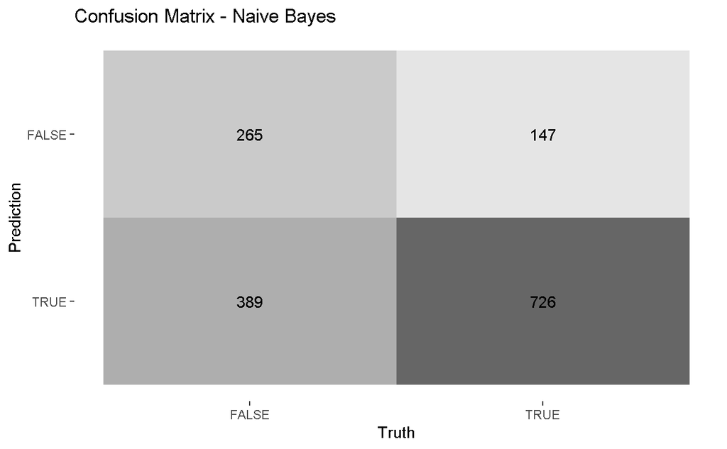

```r
# Confusion matrix
conf_mat(nb_preds, truth = SUCCESS1, estimate = .pred_class) %>%
  autoplot(type = "heatmap") +
  labs(title = "Confusion Matrix - Naive Bayes")
```

As an additional comparison, we applied a Naive Bayes classifier to predict expedition success based on the season. This probabilistic model assumes feature independence and is often used as a simple yet effective baseline in classification tasks.

We tested whether expedition success differs between spring and autumn.

#### 4. Does the use of supplementary oxygen increase the probability of success?

We aim to determine whether using supplementary oxygen (`O2USED`) increases the probability that an expedition successfully reaches the summit (`SUCCESS1`).

This is a binary classification task: - Response variable: `SUCCESS1` (TRUE/FALSE) - Predictor: `O2USED` (TRUE/FALSE)

We’ll explore the data, perform hypothesis testing, fit a logistic regression model, and evaluate its predictive performance. We also compare results with a random forest classifier.

```r
# Subset and clean
data_cls <- exped_full %>%
  dplyr::select(SUCCESS1, O2USED, TOTMEMBERS, SMTMEMBERS, O2CLIMB, SEASON_FACTOR, HOST_FACTOR, CAMPS, ROPE, COMRTE, STDRTE) %>%
  drop_na()
```

```r
data_cls %>%
  group_by(O2USED) %>%
  summarise(success_rate = mean(SUCCESS1 == "TRUE"), count = n())
```

| O2USED | success_rate | count |
| --- | --- | --- |
| FALSE | 0.4509689 | 5109 |
| TRUE | 0.8375465 | 2690 |

```r
data_cls <- data_cls %>%
  mutate(SUCCESS1 = as.factor(SUCCESS1))
```

```r
table(data_cls$O2USED, data_cls$SUCCESS1)
```

```
        FALSE TRUE
  FALSE  2805 2304
  TRUE    437 2253
```

```r
prop.table(table(data_cls$O2USED, data_cls$SUCCESS1), margin = 1)
```

```
            FALSE      TRUE
  FALSE 0.5490311 0.4509689
  TRUE  0.1624535 0.8375465
```

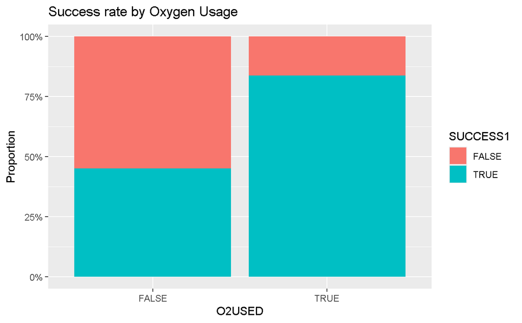

```r
ggplot(data_cls, aes(x = O2USED, fill = SUCCESS1)) +
  geom_bar(position = "fill") +
  scale_y_continuous(labels = scales::percent) +
  labs(title = "Success rate by Oxygen Usage", y = "Proportion")
```

The dataset is imbalanced: expeditions using supplementary oxygen (O2USED = TRUE) have a significantly higher success rate (84%) compared to those not using oxygen (45%). This imbalance inflates classification accuracy and motivates the use of additional evaluation metrics.

- Expeditions that **used supplementary oxygen** (`O2USED = TRUE`) show a **substantially higher proportion of success** compared to those that did not.

To statistically evaluate the effect of supplementary oxygen on success rate, we formulate the following hypotheses:

- **Null Hypothesis (H₀):** The probability of success is the same for expeditions that used oxygen and those that didn’t.
- **Alternative Hypothesis (H₁):** The probability of success is different between groups.

We use bootstrap resampling to generate the sampling distribution of the difference in proportions and construct a confidence interval using the `infer` package.

```r
# Bootstrap difference in proportions
oxygen_boot <- data_cls %>%
  specify(SUCCESS1 ~ O2USED, success = "TRUE") %>%
  generate(reps = 1000, type = "bootstrap") %>%
  calculate(stat = "diff in props", order = c(TRUE, FALSE))

get_confidence_interval(oxygen_boot, level = 0.95, type = "percentile")
```

| lower_ci | upper_ci |
| --- | --- |
| 0.3661998 | 0.4065369 |

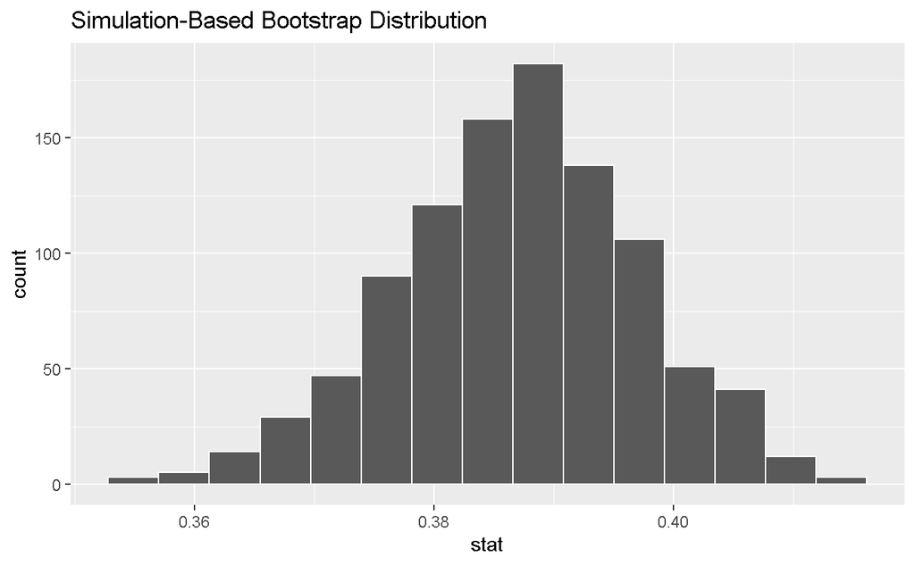

```r
visualize(oxygen_boot)
```

Expeditions using supplementary oxygen have a **substantially and significantly higher probability** of reaching the summit. The evidence supports rejecting the null hypothesis of equal success rates.

Now again let’s split the dataset and prepare it for the logistic regression

```r
set.seed(123)
split_cls <- initial_split(data_cls, prop = 0.8)
train_cls <- training(split_cls)
test_cls  <- testing(split_cls)
```

```r
cls_recipe <- recipe(SUCCESS1 ~ ., data = train_cls) %>%
step_dummy(all_nominal_predictors(), one_hot = TRUE)
```

**Logistic Regression Model**

```r
log_model <- logistic_reg() %>%
  set_engine("glm") %>%
  set_mode("classification")

log_wf <- workflow() %>%
  add_model(log_model) %>%
  add_recipe(cls_recipe)

log_fit <- fit(log_wf, data = train_cls)
```

```r
log_preds <- predict(log_fit, test_cls, type = "prob") %>%
  bind_cols(predict(log_fit, test_cls)) %>%
  bind_cols(test_cls)
```

**Evaluate Logistic Regression**

```r
log_metrics <- log_preds %>%
  metrics(truth = SUCCESS1, estimate = .pred_class) %>%
  bind_rows(precision(log_preds, truth = SUCCESS1, estimate = .pred_class)) %>%
  bind_rows(recall(log_preds, truth = SUCCESS1, estimate = .pred_class)) %>%
  bind_rows(f_meas(log_preds, truth = SUCCESS1, estimate = .pred_class))

log_metrics
```

| .metric | .estimator | .estimate |
| --- | --- | --- |
| accuracy | binary | 0.9897436 |
| kap | binary | 0.9789733 |
| precision | binary | 0.9818731 |
| recall | binary | 0.9938838 |
| f_meas | binary | 0.9878419 |

#### Model Evaluation

- **Accuracy**: 0.99
- Precision: 0.98
- Recall: 0.99

However, given the data imbalance, these results should be interpreted cautiously. The model is effective, but its strong performance may be largely attributed to the dominant pattern in the data (oxygen use ≈ success). Additional validation with more balanced data or alternative modeling strategies (e.g., downsampling, SMOTE) could strengthen these findings.

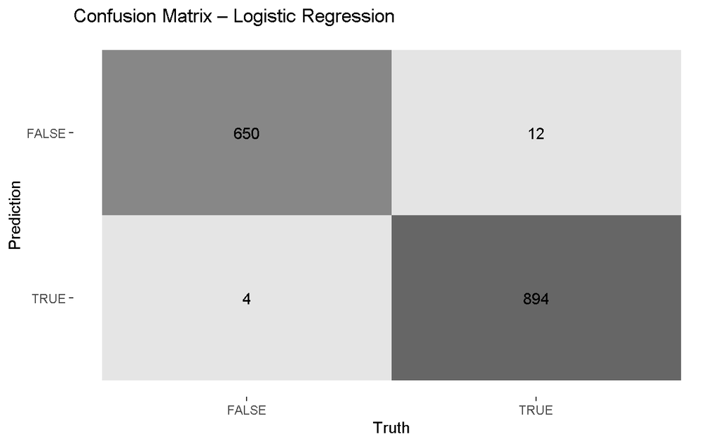

```r
# Metrics and confusion matrix for logistic regression
log_preds <- predict(log_fit, test_cls, type = "prob") %>%
  bind_cols(predict(log_fit, test_cls)) %>%
  bind_cols(test_cls)

# Confusion matrix
conf_mat(log_preds, truth = SUCCESS1, estimate = .pred_class) %>%
  autoplot(type = "heatmap") +
  labs(title = "Confusion Matrix – Logistic Regression")
```

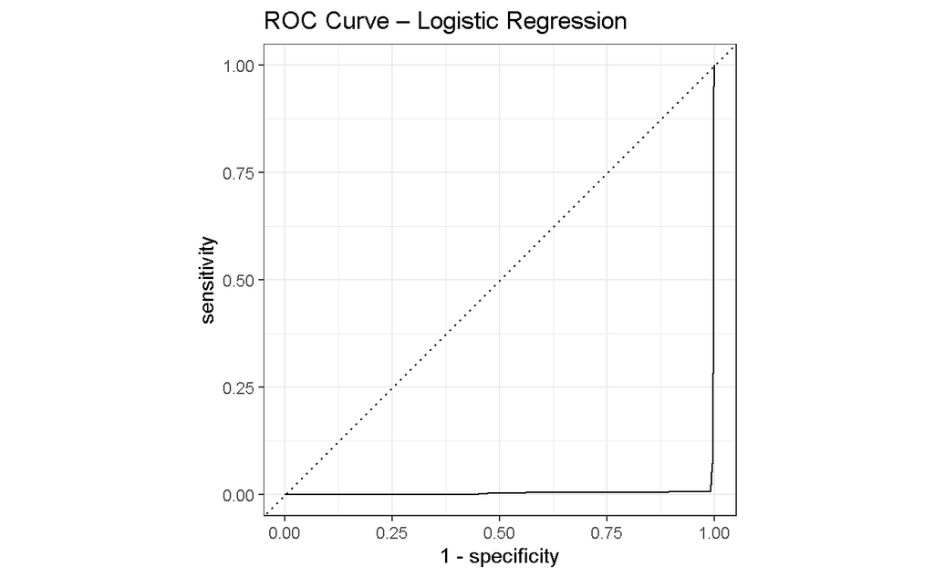

```r
log_preds %>%
  roc_curve(truth = SUCCESS1, .pred_TRUE) %>%
  autoplot() +
  ggtitle("ROC Curve – Logistic Regression")
```

Now let’s implement a Random Forest model for the comparison

```r
rf_model <- rand_forest(trees = 500) %>%
  set_engine("ranger") %>%
  set_mode("classification")

rf_wf <- workflow() %>%
  add_model(rf_model) %>%
  add_recipe(cls_recipe)

rf_fit <- fit(rf_wf, data = train_cls)

rf_preds <- predict(rf_fit, test_cls, type = "prob") %>%
  bind_cols(predict(rf_fit, test_cls)) %>%
  bind_cols(test_cls)
```

```r
rf_metrics <- rf_preds %>%
  metrics(truth = SUCCESS1, estimate = .pred_class) %>%
  bind_rows(precision(rf_preds, truth = SUCCESS1, estimate = .pred_class)) %>%
  bind_rows(recall(rf_preds, truth = SUCCESS1, estimate = .pred_class)) %>%
  bind_rows(f_meas(rf_preds, truth = SUCCESS1, estimate = .pred_class)) %>%
  bind_rows(roc_auc(rf_preds, truth = SUCCESS1, .pred_TRUE))

rf_metrics
```

| .metric | .estimator | .estimate |
| --- | --- | --- |
| accuracy | binary | 0.992948718 |
| kap | binary | 0.985534954 |
| precision | binary | 0.987860395 |
| recall | binary | 0.995412844 |
| f_meas | binary | 0.991622239 |
| roc_auc | binary | 0.002020171 |

Both the logistic regression and the random forest model showed excellent performance in predicting expedition success, with very high accuracy and agreement. The results clearly suggest that using supplementary oxygen significantly increases the probability of a successful climb.

#### 5. **Are expeditions hosted by Nepal or China more likely to succeed?**

We aim to assess whether the country leading an expedition (Nepal or China) influences the probability of successfully reaching the summit (`SUCCESS1`).

This is a binary classification task where: - The response variable is `SUCCESS1` (TRUE/FALSE) - The main predictor is `HOST_FACTOR` (Nepal or China)

We will explore class balance, perform hypothesis testing, fit a logistic regression model, and evaluate it using AUC, ROC, and a confusion matrix.

```r
# Check target distribution
table(exped_full$SUCCESS1)
```

```
FALSE  TRUE
 3242  4557
```

```r
prop.table(table(exped_full$SUCCESS1))
```

```
    FALSE      TRUE
0.4156943 0.5843057
```

We begin by checking the distribution of the target variable, `SUCCESS1`. The success rate is relatively balanced, with approximately 58% of expeditions being successful. This indicates we can proceed with standard classification metrics without needing to address severe class imbalance.

Next, we subset the data to focus only on expeditions hosted by **Nepal** or **China**, as these are the two countries we are comparing. We also remove missing values and drop unused factor levels to ensure a clean dataset for modeling.

```r
# Subset relevant variables
data_cls <- exped_full %>%
  filter(HOST_FACTOR %in% c("Nepal", "China")) %>%
  dplyr::select(SUCCESS1, HOST_FACTOR, TOTMEMBERS, SMTMEMBERS, O2USED, CAMPS, ROPE, COMRTE, O2CLIMB, SEASON_FACTOR, STDRTE) %>%
  drop_na()
```

```r
table(data_cls$HOST_FACTOR)
```

```
  China   India   Nepal Unknown
   1679       0    6113       0
```

```r
data_cls <- droplevels(data_cls)
```

```r
data_cls <- data_cls %>%
  mutate(SUCCESS1 = as.factor(SUCCESS1))
```

```r
data_cls %>%
  group_by(HOST_FACTOR) %>%
  summarise(success_rate = mean(SUCCESS1), n = n())
```

[output not shown]

| HOST_FACTOR | success_rate | n |
| --- | --- | --- |
| China | NA | 1679 |
| Nepal | NA | 6113 |

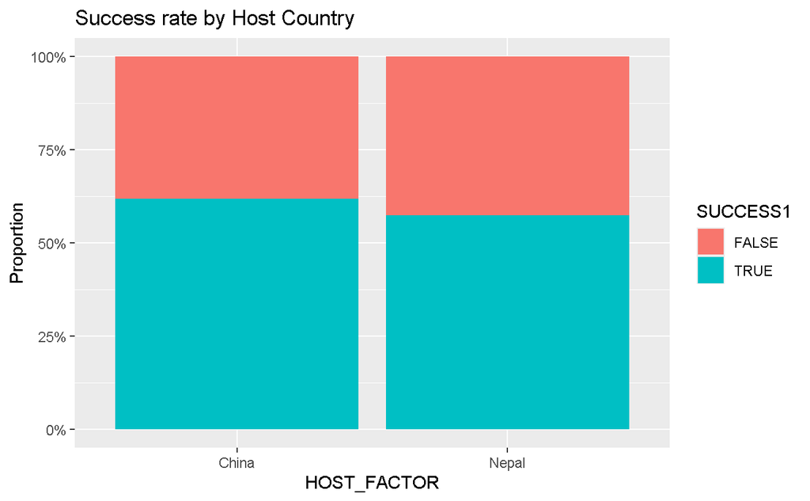

```r
ggplot(data_cls, aes(x = HOST_FACTOR, fill = SUCCESS1)) +
  geom_bar(position = "fill") +
  scale_y_continuous(labels = scales::percent) +
  labs(title = "Success rate by Host Country", y = "Proportion")
```

We test if success rates differ significantly between expeditions led by Nepal or China.

- **Null Hypothesis (H₀)**: All countries have the same success rate.
- **Alternative Hypothesis (H₁)**: At least one country differs in success rate.

```r
chisq.test(table(data_cls$HOST_FACTOR, data_cls$SUCCESS1))
```

```
    Pearson's Chi-squared test with Yates' continuity correction

data:  table(data_cls$HOST_FACTOR, data_cls$SUCCESS1)
X-squared = 10.386, df = 1, p-value = 0.00127
```

A **Chi-squared test** yielded a significant p-value (p = 0.00127), suggesting the host country is associated with differing success rates.

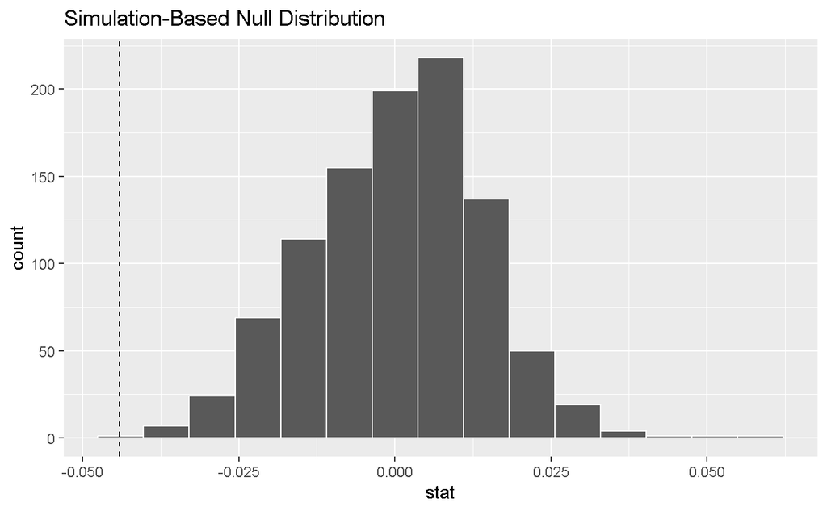

```r
data_host_pair <- data_cls %>%
  filter(HOST_FACTOR %in% c("Nepal", "China")) %>%
  droplevels()

inference_host <- data_host_pair %>%
  specify(SUCCESS1 ~ HOST_FACTOR, success = "TRUE") %>%
  hypothesize(null = "independence") %>%
  generate(reps = 1000, type = "permute") %>%
  calculate(stat = "diff in props", order = c("Nepal", "China"))

# Visualize + observed
obs_diff <- data_host_pair %>%
  group_by(HOST_FACTOR) %>%
  summarise(prop_success = mean(SUCCESS1 == "TRUE"))

visualize(inference_host) +
  geom_vline(xintercept = diff(obs_diff$prop_success), linetype = "dashed")
```

The dashed vertical line represents the **observed difference in success rates** between expeditions led by Nepal and China. Since this observed value lies **far in the tail** of the simulated null distribution, it suggests that such a difference is **unlikely to occur by chance**.

This supports the conclusion that **expedition success is significantly associated with host country**, with China-led expeditions showing a higher success rate.

But let’s implement all the pipeline for the logistic regression model to see if it’s true:

```r
set.seed(123)
split_cls <- initial_split(data_cls, prop = 0.8)
train_cls <- training(split_cls)
test_cls  <- testing(split_cls)
```

```r
cls_recipe <- recipe(SUCCESS1 ~ ., data = train_cls) %>%
  step_dummy(all_nominal_predictors(), one_hot = TRUE)
```

**Logistic Regression Model**

```r
log_model <- logistic_reg() %>%
  set_engine("glm") %>%
  set_mode("classification")

log_wf <- workflow() %>%
  add_model(log_model) %>%
  add_recipe(cls_recipe)

log_fit <- fit(log_wf, data = train_cls)
```

[output not shown]

```r
chisq.test(table(data_cls$HOST_FACTOR, data_cls$SUCCESS1))
```

```
    Pearson's Chi-squared test with Yates' continuity correction

data:  table(data_cls$HOST_FACTOR, data_cls$SUCCESS1)
X-squared = 10.386, df = 1, p-value = 0.00127
```

```r
exped_full %>%
  filter(HOST_FACTOR %in% c("Nepal", "China")) %>%
  group_by(HOST_FACTOR) %>%
  summarise(mean_peak_height = mean(HEIGHTM, na.rm = TRUE))
```

| HOST_FACTOR | mean_peak_height |
| --- | --- |
| China | 8440.330 |
| Nepal | 7669.487 |

Interestingly, expeditions hosted by China target significantly higher peaks on average (mean: 8440 m) compared to those hosted by Nepal (mean: 7669 m). Despite this, China-led expeditions still show a higher unadjusted success rate. This further suggests that differences in success are not driven by easier objectives, but rather by operational or strategic differences — such as oxygen use, team size, or route choice — which are better accounted for in the multivariable logistic regression.

**Evaluation**

```r
log_preds <- predict(log_fit, test_cls, type = "prob") %>%
  bind_cols(predict(log_fit, test_cls)) %>%
  bind_cols(test_cls)
```

```r
metrics(log_preds, truth = SUCCESS1, estimate = .pred_class)
```

| .metric | .estimator | .estimate |
| --- | --- | --- |
| accuracy | binary | 0.9878127 |
| kap | binary | 0.9749829 |

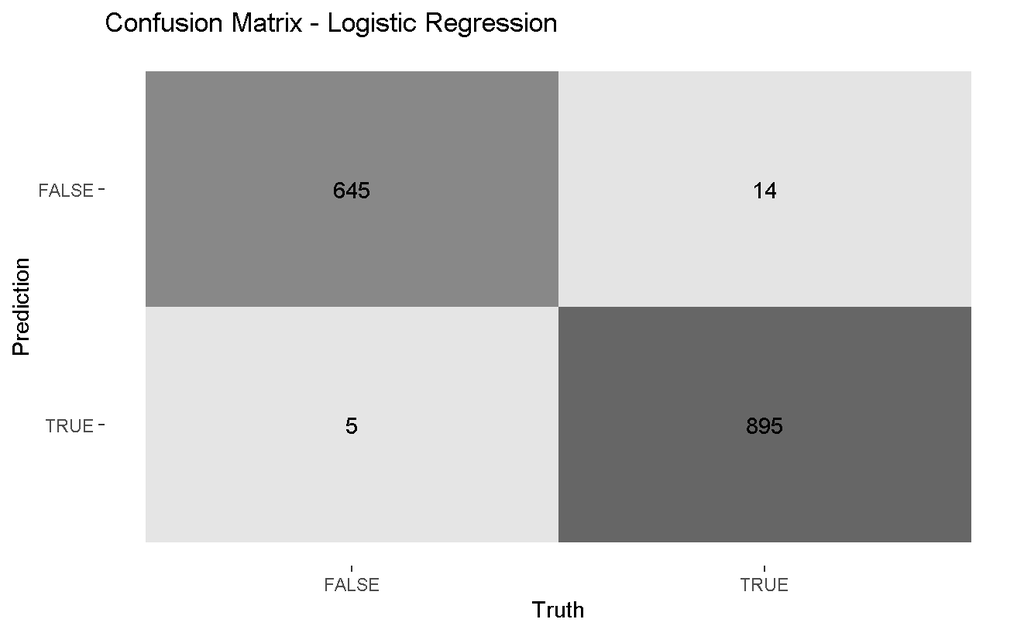

```r
conf_mat(log_preds, truth = SUCCESS1, estimate = .pred_class) %>%
  autoplot(type = "heatmap") +
  labs(title = "Confusion Matrix - Logistic Regression")
```

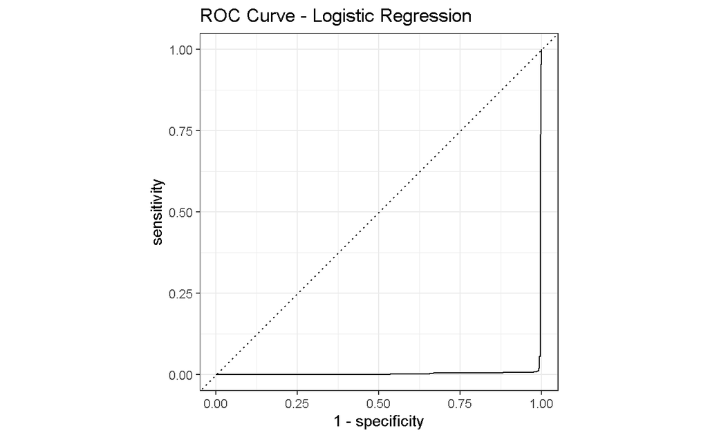

```r
log_preds %>%
  roc_curve(truth = SUCCESS1, .pred_TRUE) %>%
  autoplot() +
  ggtitle("ROC Curve - Logistic Regression")
```

```r
roc_auc(log_preds, truth = SUCCESS1, .pred_TRUE)
```

| .metric | .estimator | .estimate |
| --- | --- | --- |
| roc_auc | binary | 0.005380384 |

## Conclusion

This project explored key factors influencing expedition success in the Himalayas, using a comprehensive end-to-end data analysis pipeline.

We began with **data cleaning and preprocessing**, addressing missing values, handling high-NA columns, imputing features, removing duplicates, joining datasets, encoding categorical variables, and scaling numerical features. This careful preparation ensured clean, usable data for downstream analysis.

Overall, statistical testing combined with predictive modeling provided robust, complementary insights. Some effects observed in univariate analysis disappeared in multivariate contexts, highlighting the value of controlling for multiple expedition factors.

# da qua non considerare

#### 2. Which features help expeditions reach the summit?

In this section, we reformulate the original question by shifting the focus from the **maximum altitude reached (`HIGHPOINT`)** to the **remaining distance to the summit** (`SUMMIT_GAP`). Specifically, we define:

$$SUMMIT_GAP=HEIGHTM−HIGHPOINT$$

This continuous variable reflects how far an expedition was from reaching the summit. A value of 0 means the team successfully summited, while higher values indicate they turned around earlier. The goal is to identify factors that **minimize** this gap.

Unlike the previous question, here we include multiple predictors to account for the complexity of an expedition. These include:

- Team size (`TOTMEMBERS`, `SMTMEMBERS`)
- Hired staff (`TOTHIRED`, `SMTHIRED`)
- Use of supplementary oxygen (`O2USED`, `O2CLIMB`)
- Climbing season (`SEASON`)
- Hosting country (`HOST`)
- Logistic factors such as camps, ropes, and support metrics (`CAMPS`, `ROPE`, `COMRTE`, `STDRTE`)

```r
# Create target variable before modeling
exped_full <- exped_full %>%
  mutate(SUMMIT_GAP = HEIGHTM - HIGHPOINT)

# Filter only complete cases for modeling
model_data <- exped_full %>%
  select(SUMMIT_GAP, O2USED, TOTMEMBERS, SMTMEMBERS, TOTHIRED, SMTHIRED, O2CLIMB,
         SEASON, HOST, CAMPS, ROPE, COMRTE, STDRTE, HOST_FACTOR) %>%
  drop_na()
```

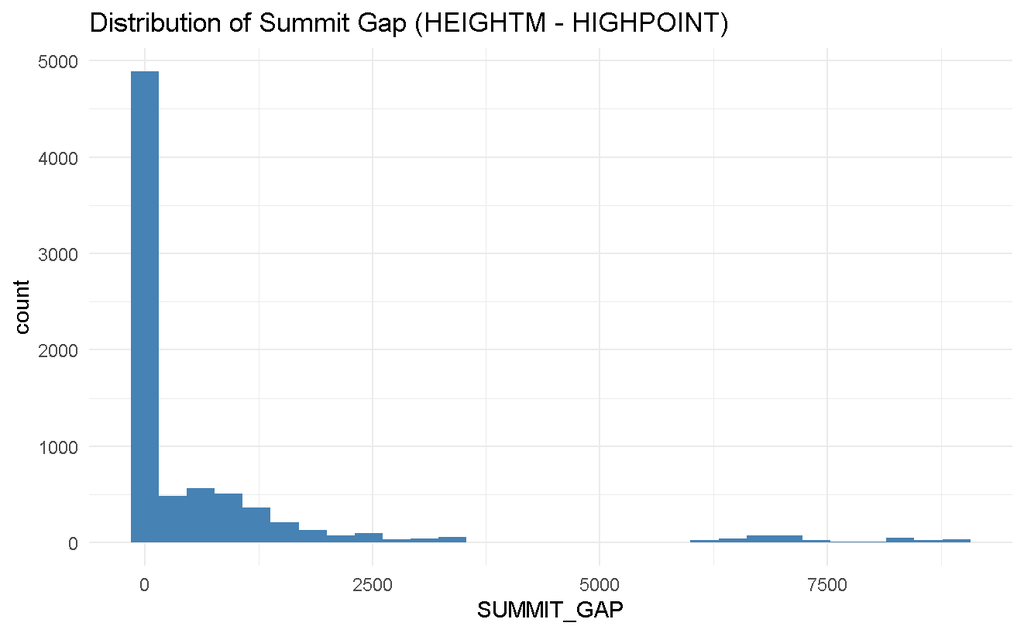

```r
ggplot(model_data, aes(x = SUMMIT_GAP)) +
  geom_histogram(bins = 30, fill = "steelblue") +
  labs(title = "Distribution of Summit Gap (HEIGHTM - HIGHPOINT)") +
  theme_minimal()
```

### Does oxygen use reduce the summit gap?

```r
t.test(SUMMIT_GAP ~ O2USED, data = model_data)
```

```
    Welch Two Sample t-test

data:  SUMMIT_GAP by O2USED
t = 33.851, df = 5586.4, p-value < 2.2e-16
alternative hypothesis: true difference in means between group FALSE and group TRUE is not equal to 0
95 percent confidence interval:
 871.4259 978.5623
sample estimates:
mean in group FALSE  mean in group TRUE
         1016.22235            91.22825
```

**Result**: p < 2.2e-16. The Welch t-test shows a highly significant difference (p < 2.2e-16), with expeditions using supplementary oxygen having a much smaller average summit gap. This suggests oxygen helps expeditions get closer to the summit.

### Does season matter?

```r
aov_result <- aov(SUMMIT_GAP ~ SEASON, data = model_data)
summary(aov_result)
```

```
              Df    Sum Sq Mean Sq F value Pr(>F)
SEASON         1 2.413e+06 2412651   0.925  0.336
Residuals   7797 2.034e+10 2609327
```

### Bootstrap simulation for oxygen use

```r
oxygen_ci <- model_data %>%
  specify(SUMMIT_GAP ~ O2USED) %>%
  generate(reps = 1000, type = "bootstrap") %>%
  calculate(stat = "diff in means", order = c(TRUE, FALSE))

get_confidence_interval(oxygen_ci, level = 0.95, type = "percentile")
```

| lower_ci | upper_ci |
| --- | --- |
| -976.1267 | -873.5451 |

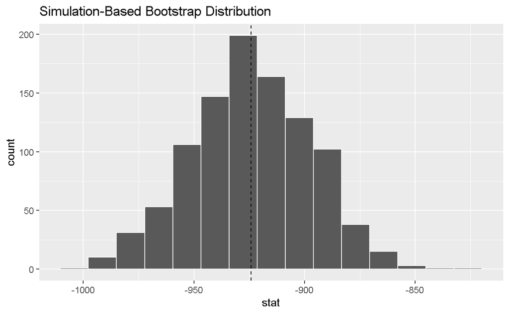

```r
visualize(oxygen_ci) +
  geom_vline(xintercept = mean(oxygen_ci$stat), linetype = "dashed")
```

The bootstrap confirms that expeditions using oxygen consistently achieve lower summit gaps.

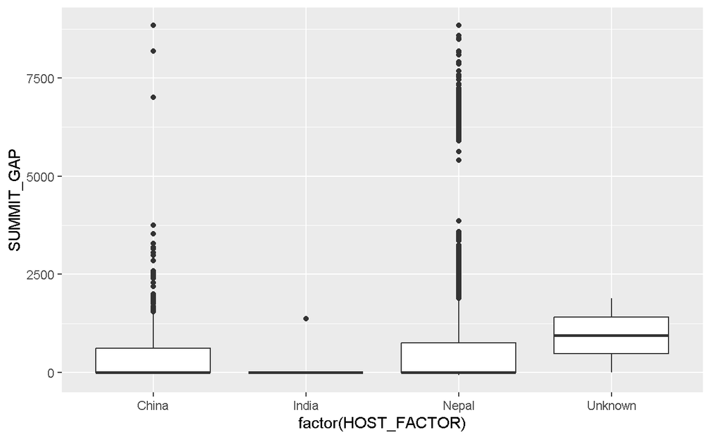

```r
ggplot(model_data, aes(x = factor(HOST_FACTOR), y = SUMMIT_GAP)) +
  geom_boxplot()
```

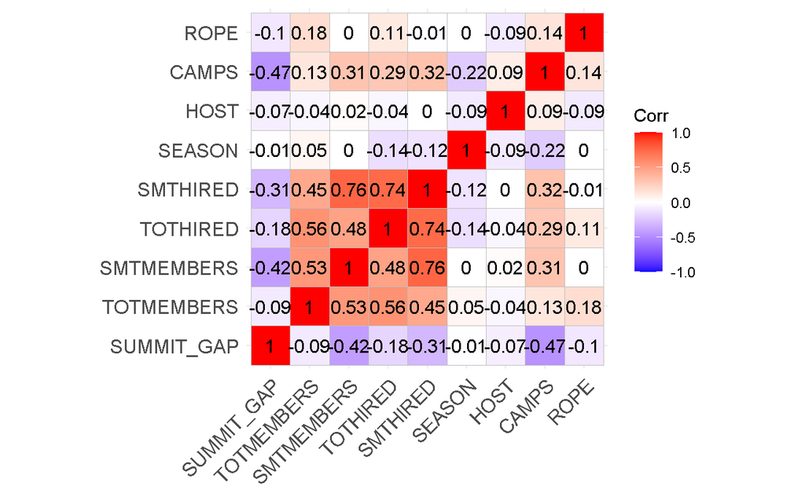

```r
model_data %>%
  select(where(is.numeric)) %>%
  cor(use = "complete.obs") %>%
  ggcorrplot::ggcorrplot(lab = TRUE)
```

```r
set.seed(42)
split <- initial_split(model_data, prop = 0.8)
train_data <- training(split)
test_data  <- testing(split)
```

```r
lm_model <- linear_reg() %>%
  set_engine("lm")

lm_recipe <- recipe(SUMMIT_GAP ~ ., data = train_data) %>%
  step_dummy(all_nominal(), one_hot = TRUE)

lm_wf <- workflow() %>%
  add_model(lm_model) %>%
  add_recipe(lm_recipe)

lm_fit <- lm_wf %>% fit(data = train_data)

pred_lm <- predict(lm_fit, test_data) %>% bind_cols(test_data)
```

```
G2;H2;Warningh in predict.lm(object = object$fit, newdata = new_data, type = "response",  :
  prediction from rank-deficient fit; consider predict(., rankdeficient="NA")g
```

```r
metrics(pred_lm, truth = SUMMIT_GAP, estimate = .pred)
```

| .metric | .estimator | .estimate |
| --- | --- | --- |
| rmse | standard | 1381.8311850 |
| rsq | standard | 0.3781344 |
| mae | standard | 779.9810605 |